# Practical Machine Learning Course Project

Diandian Yi

11/27/2019

# Summary

This project investigated what and how the factors affecting the manner in which the subjects did the exercise by using the Human Activity recognition data http://web.archive.org/web/20161224072740/http:/groupware.les.inf.puc-rio.br/har.Given the possibility nowadays that we can collect a large amount of data about personal activity relatively inexpensively using devices such as Jawbone Up, Nike Fuelband, and Fitbit, this data is from accelerometers on the belt, forearm, arm and dumbell of 6 participants. These participants(subjects) were asked to perform barbell lifts correctly and incorrectly in 5 different ways. In the training set, the manner(how well they do it) has been recorded as a factor variable “classe” with 5 levels: A, B, C, D, E.

# Clean the data and some exploratory analysis

To import and clean the data, I ruled out all the variables in original training dataset that have no variation and contain lots of null values. Then I changed the data type of column named “cvtd_timestamp” into date.

1. Import the data

```r
getwd()
setwd("/Users/yidiandian/CourseraProjects/PracticalMachineLearning")
library(ggplot2)
library(caret)
library(corrplot)
library(tidyverse)
library(e1071)
library(rattle)
library(randomForest)
library(mlbench)

pml_testing <- read.csv("./pml-testing.csv")
pml_training <- read.csv("./pml-training.csv")
```

2. Rule out the variables that are not near to zero value and not null

```r
nearZeroVar <- nearZeroVar(pml_training,saveMetrics = TRUE)
nonZeroVariables <- rownames(nearZeroVar[nearZeroVar$nzv==FALSE,])
pml_training_nonzero <- pml_training[,nonZeroVariables]
nullcol <- sapply(pml_training_nonzero,function(x)sum(is.na(x)))
nonullVariables <- names(nullcol[nullcol==0])
pml_training_nonzeronull <- pml_training_nonzero[,nonullVariables]
```

3. Change the format of the timestamp column into date/time

```r
pml_training_nonzeronull$cvtd_timestamp <- as.POSIXct(as.character(pml_training_nonzeronull$cvtd_timestamp),format="%d/%m/%Y %H:%M")
```

Until now, I got a clean dataset and when I look at the classifier “classe”, I found basically I have a balanced classifier in the dataset.

```r
sapply(pml_training_nonzeronull,function(x)sum(is.na(x)))
```

```
##                    X            user_name raw_timestamp_part_1
##                    0                    0                    0
## raw_timestamp_part_2       cvtd_timestamp           num_window
##                    0                    0                    0
##            roll_belt           pitch_belt             yaw_belt
##                    0                    0                    0
##     total_accel_belt         gyros_belt_x         gyros_belt_y
##                    0                    0                    0
##         gyros_belt_z         accel_belt_x         accel_belt_y
##                    0                    0                    0
##         accel_belt_z        magnet_belt_x        magnet_belt_y
##                    0                    0                    0
##        magnet_belt_z             roll_arm            pitch_arm
##                    0                    0                    0
##              yaw_arm      total_accel_arm          gyros_arm_x
##                    0                    0                    0
##          gyros_arm_y          gyros_arm_z          accel_arm_x
##                    0                    0                    0
##          accel_arm_y          accel_arm_z         magnet_arm_x
##                    0                    0                    0
##         magnet_arm_y         magnet_arm_z        roll_dumbbell
##                    0                    0                    0
##       pitch_dumbbell         yaw_dumbbell total_accel_dumbbell
##                    0                    0                    0
##     gyros_dumbbell_x     gyros_dumbbell_y     gyros_dumbbell_z
##                    0                    0                    0
##     accel_dumbbell_x     accel_dumbbell_y     accel_dumbbell_z
##                    0                    0                    0
##    magnet_dumbbell_x    magnet_dumbbell_y    magnet_dumbbell_z
##                    0                    0                    0
##         roll_forearm        pitch_forearm          yaw_forearm
##                    0                    0                    0
##  total_accel_forearm      gyros_forearm_x      gyros_forearm_y
##                    0                    0                    0
##      gyros_forearm_z      accel_forearm_x      accel_forearm_y
##                    0                    0                    0
##      accel_forearm_z     magnet_forearm_x     magnet_forearm_y
##                    0                    0                    0
##     magnet_forearm_z               classe
##                    0                    0
```

```r
table(pml_training_nonzeronull$classe)
```

```
##
##    A    B    C    D    E
## 5580 3797 3422 3216 3607
```

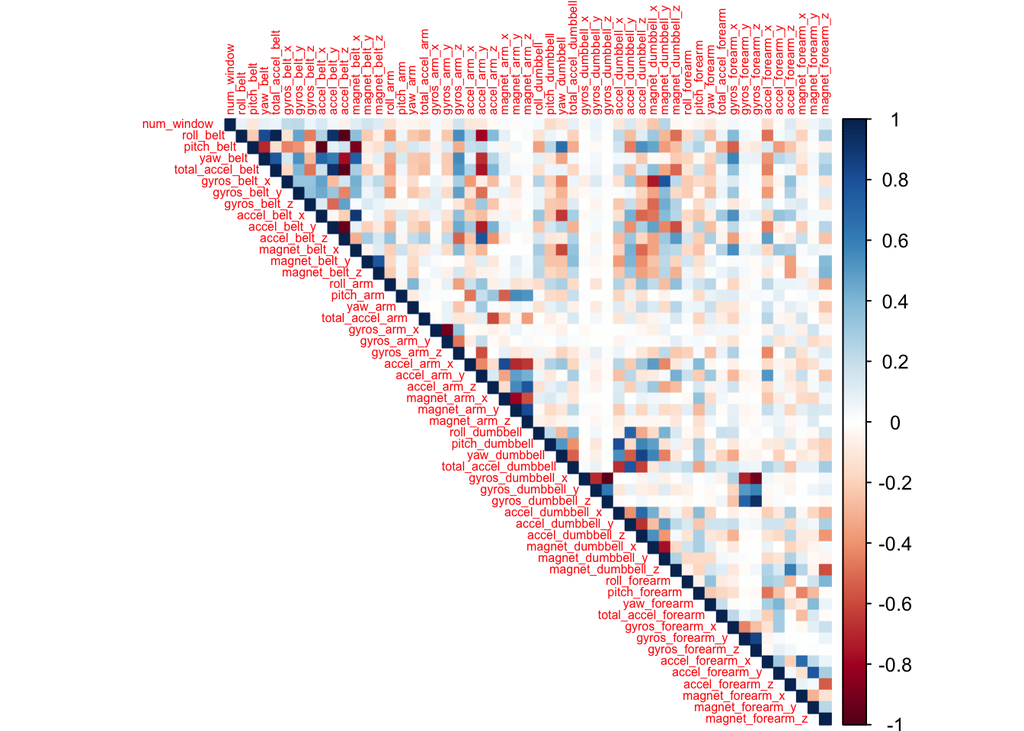

```r
corr.matrix <- cor(pml_training_nonzeronull[,c(6:58)])
corrplot(corr.matrix, method="color",tl.cex=0.5,type="upper")
```

```r
pml_training_nonzeronull_features <- pml_training_nonzeronull[,c(6:59)]
```

# Model building

I tried decision trees and random forest algorithm to run the model.

1. Decision trees

I used repeated k-fold cross validation to validate my model. For parameters I set k = 10, and repeats = 3.

[figure not shown]

```r
set.seed(1234)
##repeated k-fold cross validation
model_rpart_repeatedcv <- caret::train(classe ~ .,
                                  data = pml_training_nonzeronull_features,
                                  method = "rpart",
                                  preProcess = c("scale", "center"),
                                  trControl = trainControl(method = "repeatedcv",
                                               number = 10, repeats = 3))
fancyRpartPlot(model_rpart_repeatedcv$finalModel)
```

According to the model summary, the accuracy is highest when cp = 0.03891896. But the average accuracy is only around 54%, I tried random forest to improve the accuracy.

```r
print(model_rpart_repeatedcv)
```

```
## CART
##
## 19622 samples
##    53 predictor
##     5 classes: 'A', 'B', 'C', 'D', 'E'
##
## Pre-processing: scaled (53), centered (53)
## Resampling: Cross-Validated (10 fold, repeated 3 times)
## Summary of sample sizes: 17661, 17659, 17659, 17660, 17659, 17659, ...
## Resampling results across tuning parameters:
##
##   cp          Accuracy   Kappa
##   0.03891896  0.5323292  0.3979631
##   0.05998671  0.4155140  0.2076844
##   0.11515454  0.3210848  0.0559098
##
## Accuracy was used to select the optimal model using the largest value.
## The final value used for the model was cp = 0.03891896.
```

2. Random forest

To balance the accuracy of the prediction of the model and the computational demand of the model, I employed k-fold cross validation and set k = 3. To tune the parameter for the random forest, I used random search to tune mtry and set tuneLength = 5.

```r
control <- trainControl(method='cv',
                        number= 3,
                        search = 'random')

##Random generate 5 mtry values with tuneLength = 5
set.seed(1)
model_rf_random <- train(classe ~ .,
                   data = pml_training_nonzeronull_features,
                   method = 'rf',
                   tuneLength  = 5,
                   trControl = control)
```

According to the model summary, the accuracy is highest when mtry = 23. With this parameter, the accuracy is 99.72480%, and the Kappa equals 99.65189%.

```r
print(model_rf_random)
```

```
## Random Forest
##
## 19622 samples
##    53 predictor
##     5 classes: 'A', 'B', 'C', 'D', 'E'
##
## No pre-processing
## Resampling: Cross-Validated (3 fold)
## Summary of sample sizes: 13081, 13082, 13081
## Resampling results across tuning parameters:
##
##   mtry  Accuracy   Kappa
##    1    0.9907758  0.9883301
##   23    0.9972480  0.9965189
##   34    0.9966874  0.9958096
##   39    0.9959230  0.9948424
##   43    0.9954644  0.9942621
##
## Accuracy was used to select the optimal model using the largest value.
## The final value used for the model was mtry = 23.
```

# Prediction

Based on the model with random forest algorithm, the prediction for the test dataset is like below:

```r
Prediction_rf <- predict(model_rf_random, newdata = pml_testing)
Prediction_rf
```

```
##  [1] B A B A A E D B A A B C B A E E A B B B
## Levels: A B C D E
```